[figure not shown]

1021McAllister D,A, etal. Arch Dis Child 2018;103:1021–1026. doi:10.1136/archdischild-2017-314354

Original article

Enhanced detection services for developmental

dysplasia of the hip in Scottish children, 1997–2013

David, A McAllister,

1,2

Joanne, R Morling,

3

Colin, M Fischbacher,

2

Mike Reidy,

4

Alastair Murray,

5

Rachael Wood

2,6

To cite: McAllisterD,A,

MorlingJ,R, FischbacherC,M,

etal. Arch Dis Child

2018;103:1021–1026.

► Additional material is

published online only. To view

please visit the journal online

(http:// dx. doi. org/ 10. 1136/

archdischild- 2017- 314354).

1

Institute of Health and

Wellbeing, University of

Glasgow, Glasgow, UK

2

NHS Information Services

Division, NHS National Services

Scotland, Edinburgh, UK

3

Division of Epidemiology and

Public Health, University of

Nottingham, Nottingham, UK

4

Orthopaedics Department, NHS

Tayside, Edinburgh, UK

5

Royal Hospital for Sick

Children, NHS Lothian,

Edinburgh, UK

6

Child Life and Health,

University of Edinburgh,

Edinburgh, UK

Correspondence to

DrDavid and AMcAllister,

University of Glasgow, Institute

of Health and Wellbeing,

Glasgow G12 8RZ, UK;

david. mcallister@ glasgow. ac. uk

Received 23 October 2017

Revised 10 January 2018

Accepted 17 January 2018

Published Online First

7February2018

► http:// dx. doi. org/ 10. 1136/

archdischild- 2018- 314813

What is alreadyknown on this topic?

► Developmental dysplasia of the hip is the

most common congenital lower limb problem

affecting children.

► If identiﬁed early, conservative management

with an abduction harness usually results

in a good outcome, requiring no further

intervention. Nonetheless, the role of screening

is contested.

What this study adds?

► The introduction of enhanced newborn

screening for developmental dysplasia of the

hip was associated with a halving of rates of

subsequent corrective surgery.

► On the basis of this evidence, wider

implementation of enhanced developmental

dysplasia of the hipscreening appears to be

justiﬁable.

ABSTRACT

Background Developmental dysplasia of the hip

(DDH) remains common. If detected early, DDH can

usually be corrected with conservative management.

Late presentations often require surgery and have worse

outcomes.

Objective We estimated the risk of undergoing surgery

for DDH by age 3 years before and after the introduction

of enhanced DDH detection services.

Design Retrospective cohort study.

Setting Scotland, 1997/98–2010/11.

Patients All children.

Methods Using routinely collected national hospital

discharge records, we examined rates of ﬁrst surgery

for DDH by age 3 by March 2014. Using a difference

in difference analysis, we compared rates in two areas

of Scotland before (to April 2002) and after (from April

2005) implementation of enhanced DDH detection

services to those seen in the rest of Scotland.

Results For children born in the study period, the risk of

ﬁrst surgery for DDH by age 3 was 1.18 (95% CI 1.11 to

1.26) per 1000 live births (918/777 375).

Prior to April 2002, the risk of surgery was 1.13 (95% CI

0.88 to 1.42) and 1.31 (95% CI 1.16 to 1.46) per 1000

live births in the intervention and non-intervention areas,

respectively. In the intervention areas, from April 2005,

this risk halved (RR 0.47; 95% CI 0.32 to 0.68). The risk

remained unchanged in other areas (RR 1.01; 95% CI

0.86 to 1.18). The ratio for the difference in change of

risk was 0.46 (95% CI 0.31 to 0.70).

Conclusions The implementation of enhanced DDH

detection services can produce substantial reductions

in the number of children having surgical correction for

DDH.

INTRODUCTION

Developmental dysplasia of the hip (DDH), ranges

from a physiologically immature hip joint that

spontaneously resolves to an irreducible dislocation

of the hip joint requiring surgical intervention. It is

the most common congenital lower limb problem

affecting children.

1

If diagnosed within the first 10 weeks of life,

most cases requiring treatment can be managed

conservatively with abduction harnessing resulting

in a good outcome, requiring no further interven-

tion.

2

After this age, there is a progressive increase

in the need for surgery and the risk of poorer

outcomes,

3 4

which identifies DDH as a potential

target for screening.

There is a lack of adequately powered clinical

trials concerning how children should be screened

for DDH,

5

however. Consequently, international

practice varies,

6–9

and there is also disagreement

between professional bodies. The US Preventive

Services Task Force statement from 2006,

8

which

has not been updated, states that ‘evidence is insuf-

ficient to recommend routine screening for DDH in

infants as a means to prevent adverse outcomes’. In

contradiction, the American Academy of Paediatrics

recommends that all newborns should be screened

by physical examination.

7

Evidence from case series and historical compar-

isons does suggest that enhanced models of DDH

detection involving expert examiners or increased

use of ultrasound imaging may improve early

diagnosis and reduce the likelihood of children

requiring surgical treatment.

9–12

In the light of this,

two of the 14 geographical National Health Service

(NHS) entities within Scotland have independently

introduced enhanced DDH detection services. In

2002, NHS Lothian appointed an extended scope

physiotherapist to lead a DDH detection service

and in 2004 NHS Fife employed a physician with

an interest in DDH.

In Scotland, national data are not collected on

newborn physical examinations, nor on radiolog-

ical investigations or conservative treatment for

DDH provided in outpatient settings. National

hospital discharge records are available, however,

providing information on day case and inpatient

[figure not shown]

Original article

surgical procedures. A surgical procedure for DDH in child-

hood indicates that a child has either failed conservative treat-

ment or, more likely, presented too late for such treatment to

be attempted. Rates of surgical intervention can therefore be

considered as a surrogate marker for late presentation.

13

Therefore, we used nationally available hospital discharge

records (1) to estimate the risk of surgery for DDH before,

during and after the introduction of enhanced DDH detection

services in the two geographic areas, compared with the rest of

Scotland and (2) to describe the risk of surgery according to sex,

deprivation and year of birth.

METHODS

Population

Children were included in the study population if they were born

in Scotland between April 1997 and March 2013. The number

of live births in each financial year 1997/1998 to 2012/13

was obtained from statutory birth registration records held by

National Records for Scotland.

14

Outcomes

All surgical operations in Scotland are recorded in a national

database (Scottish Morbidity Record 01) alongside a unique

identifier for each individual as well as their age, sex and area

of residence as well as up to six diagnostic codes (WHO Tenth

International Statistical Classification of Diseases and Related

Health Problems (ICD 10)) and four procedure codes (Office

of Population Censuses and Surveys Fourth Classification of

Interventions and Procedures).

15

Using this database, we defined

surgical intervention for DDH as any record with a relevant

diagnostic code (ICD-10 Q65.0–9) and procedure code (T20.2,

T20.5, W13.4, W14.4, W16.4, W16.9, W28.1, X22.1–9,

W65-6). Code labels are provided in etable 1 in the online

Supplementary data. Records identified using these codes were

tested against an operative database in NHS Lothian covering

2008–2013 and found to have a 98% concordance. First surgery

for DDH was defined as the first DDH procedure for any child

in the study population any time up to March 2014. Birth data

were matched to first operation data by sex, year of birth, area

of residence and deprivation quintile.

Intervention

In line with national guidance,

16

standard care in Scotland is that

children are examined using the Ortolani and Barlow tests shortly

after birth in maternity units (by junior doctors, physiotherapists

and/or midwives) and again during the 6–8 week universal child

health review (usually by primary care physicians). Children

with abnormal findings at a newborn or 6–8 week examination

or with recognised risk factors for DDH (eg, breech presenta-

tion, family history or moulding abnormality) are referred to

specialist services for further investigation, although the detail of

service pathways varies between areas.

In two areas of Scotland, enhanced models of DDH detection

involving expert examiners or increased use of ultrasound imaging

were introduced. NHS Fife serves a population of 350 000 with

approximately 3900 births per year, with all maternity services

provided from a single large secondary centre. NHS Lothian serves

a population of 765 000 with approximately 9000 births per year,

with maternity services provided from a large tertiary centre and a

smaller district general hospital. NHS Lothian is somewhat more

In 2002, in NHS Lothian, after a 2-year training period, a

physiotherapist was appointed to an enhanced role where 75%

of their time was assigned to the prevention and treatment of

DDH. This included a presence on postnatal wards examining

newborns, training and supporting paediatric medical staff

performing hip examination, promoting awareness of DDH in

the postnatal setting and delivering a weekly clinic for secondary

examinations with ultrasound support and harnessing treatment.

Less than 25% of this time was spent on direct patient contact,

with the majority being spent providing training and promoting

awareness. The service was enhanced in 2008 with the addition

of a second extended scope physiotherapist.

In 2004, in NHS Fife, a physician with broad responsibilities for

delivering paediatric orthopaedic care began a weekly hip exam-

ination and ultrasound clinic for detection and treatment of DDH

and provided routine training and education for the paediatric and

maternity teams responsible for newborn physical examinations.

Expert examination and ultrasound were performed in 31% of all

live births in Fife between 2004 and 2013.

The time period for the introduction of the intervention to

both areas (hereafter, introduction period) was defined as the

financial years from April 2002 to April 2005. The incidence

of surgery for DDH was compared before, during and after this

period. For the purposes of the analysis, any child born after

the introduction period and who was resident in either of the

two NHS areas within Scotland where the quality improvement

programmes were initiated was assumed to have received the

intervention. To test the robustness of our findings, we also

varied the definition of both the start and end of the introduc-

tion period by ±1 year and ±2 years.

Deprivation

Deprivation quintile was defined using the Scottish Index of

Multiple Deprivation, a small area-based measure of multiple

material deprivation, with children assigned to a popula-

tion-based deprivation quintile based on their postcode of resi-

dence at birth or surgery.

17

Statistical analysis

The risk of surgery per 1000 live births and 95% CI by patient

characteristics was estimated by sampling from a beta distribu-

tion with a Jeffrey’s prior, as this has excellent frequentist prop-

erties.

18

The change in the 3 year odds of surgery for children

born in the intervention areas before and after the intervention

period was compared with the change in odds for children born

in other areas using a logistic regression model, with a period/

area interaction term to obtain a difference in difference compar-

ison. Logistic regression was also used to model the risk of a

surgical event for girls versus boys, each deprivation quintile (vs

most deprived quintile) and each year of birth (vs 1997/1998).

Analyses were undertaken both unadjusted and adjusted for each

of the other covariates: adjustment made minimal difference to

results and hence only unadjusted results are reported. As the

risk of the outcome was low, these OR may be interpreted as

relative risks (RR) (ie, risk ratios) and are presented as such to

aid interpretability.

All analyses were performed within the Information Services

Division of NHS National Services Scotland, with only aggregate

results subsequently released, and hence ethical approval was not

required. Missing covariate data were extremely uncommon and

so we used complete case analysis. Analyses were undertaken using

SPSS V.21.0 and R V.3.2.0 (R Foundation, Vienna, Austria).

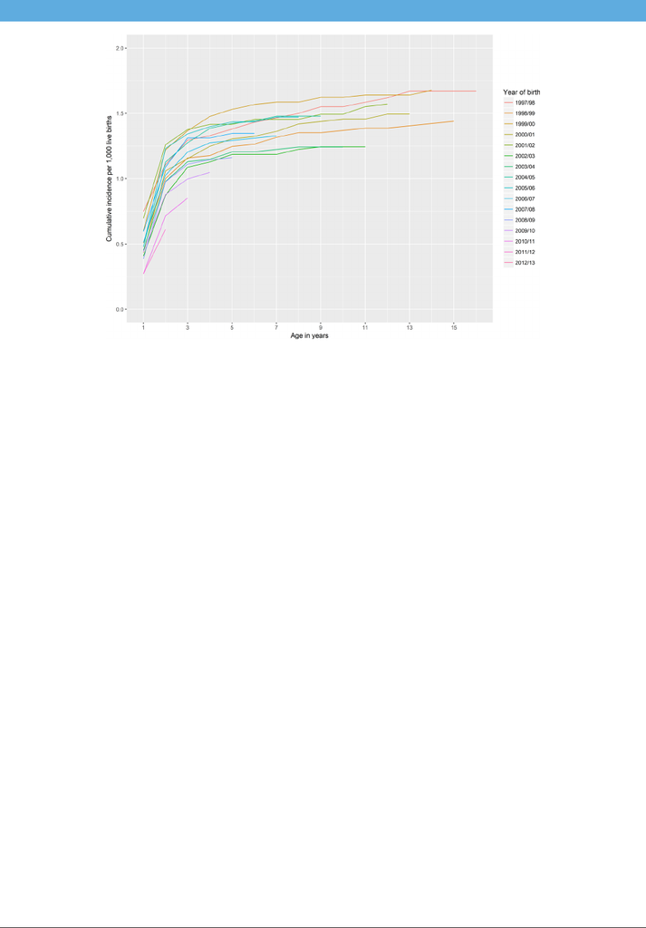

Original article

Figure 1 Cumulative incidence of ﬁrst surgical intervention for developmental dysplasia of the hip by age up to 16 years, children born 1997/1998

to 2012/2013, Scotland.

RESULTS

There were 896 594 live births and 1103 first surgical inter-

ventions for DDH in Scotland up to end March 2014 among

children born in the financial years 1997/1998 to 2012/2013

inclusive. For children born in 1997/1998, the risk of surgery

by age 16 years was 1.67 per 1000 live births, or around one in

600 births.

Around 80% of operations occurred in children aged 3

years and younger (see etable 2 in the online Supplementary

data, figure 1). Among the 780 475 live births in the period

1997/1998 to 2010/2011 (ie, the period where data were avail-

able for all children up to the age of 3), there were 927 cases of

first surgery by age 3 years. For 3100 (0.4%) live births and for

nine children who had surgery, there was missing data on sex,

deprivation or area of residence. Among the remaining 777 375

births, the risk of surgery by age 3 years was 1.18 (95 %CI 1.11

to 1.26) per 1000 births. Risk was more than six times higher

in girls than boys (RR 6.20; 5.16 to 7.46) and was lowest in the

most deprived quintile compared with the remaining depriva-

tion quintiles (RR for most deprived quintile vs middle quintile

0.71; 95% CI 0.58 to 0.87, table 1).

The risk of surgery at age 3 or younger before the introduc-

tion period was 1.30 and 1.13 per 1000 live births and 1.32

and 0.54 per 1000 live births after the introduction period for

children born in non-intervention areas and intervention areas,

respectively. For the children born in the intervention areas, this

risk halved (RR after vs before introduction period 0.47; 95% CI

0.32 to 0.68, table 2, figure 2). Over this same time period, there

was no evidence of a fall in risk for children born in non-inter-

vention areas (RR 1.01; 95% CI 0.86 to 1.18). Therefore, the

RR for the difference in after-introduction versus before-intro-

duction risk in the intervention areas compared with the differ-

ence in after-introduction versus before-introduction risk in

other geographic areas was 0.46 (95% CI 0.31 to 0.70).

In subsequent analyses, which had not been prespecified, we

estimated the difference in after-introduction versus before-in-

troduction risk in intervention compared with non-intervention

areas separately for Fife and Lothian; the RRs were 0.42 (95%

CI 0.22 to 0.81) and 0.49 (95% CI 0.29 to 0.81), respectively.

In sensitivity analyses, varying the definition of both the start

and end of the introduction period by ±1 year and ±2 years

either side of the dates defined in the main analysis, similar asso-

ciations were found. Across the sensitivity analyses, the interac-

tion (ie, difference in difference) RRs varied from 0.33 (95% CI

0.21 to 0.52) to 0.58 (95% CI 0.39 to 0.87; see eFigure 2 in the

online Supplementary data).

DISCUSSION

In a study of all children born in Scotland over a 14-year

period, we found that, following the introduction of enhanced

DDH detection services, the risk of surgery for DDH in two

geographic areas halved. No change in risk was seen for children

born in other areas.

Our analysis exploited a natural experiment—a dramatic

change in practice in selected areas of Scotland. Two of the 14

health boards in Scotland independently introduced enhanced

DDH detection services; the remaining 12 areas continued with

practice-as-usual. Using high-quality routine healthcare data for

the whole of Scotland, we were therefore able to compare the

risk of surgery for DDH across intervention and non-interven-

tion areas before and after the introduction of these services.

Therefore, this finding adds considerably to the evidence base on

the effectiveness of DDH detection services.

While randomised clinical trials generally provide the stron-

gest evidence for the effectiveness of diagnostic approaches,

trials examining enhanced approaches to DDH detection have

been limited by the rarity of the outcome. For example, in a

2011 Cochrane systematic review of randomised and pseu-

dorandomised trials examining screening, only one study was

identified which compared clinical examination alone to clin-

ical examination plus targeted and/or universal ultrasound

screening.

5

The incidence of late surgery was lower in groups

allocated (in a pseudorandomsied design) to ultrasound (RR

[figure not shown]

Original article

Table 1 Risk of ﬁrst surgical intervention for developmental dysplasia of the hip by age 3 years, Scotland, children born 1997/1998–2010/2011,

by sex, deprivation quintile and year of birth

Live births Number of children Risk per 1000 live births (95% CI) Relative risk (95% CI)

Male 398 036 133 0.34 (0.28 to 0.40) 1.00 (ref)

Female 379 339 785 2.07 (1.93 to 2.22) 6.20 (5.16 to 7.46)

Deprivation

1 (most deprived) 193 500 183 0.95 (0.82 to 1.09) 1.00 (ref)

2 157 246 193 1.23 (1.07 to 1.41) 1.30 (1.06 to 1.59)

3 144 944 193 1.33 (1.16 to 1.53) 1.41 (1.15 to 1.72)

4 144 096 188 1.31 (1.13 to 1.51) 1.38 (1.13 to 1.69)

5 (least deprived) 137 589 161 1.17 (1.00 to 1.36) 1.24 (1.00 to 1.53)

Year

1997/1998 58 395 76 1.31 (1.04 to 1.61) 1.00 (ref)

1998/1999 56 728 66 1.17 (0.91 to 1.47) 0.89 (0.64 to 1.24)

1999/2000 54 636 74 1.36 (1.07 to 1.69) 1.04 (0.76 to 1.43)

2000/2001 52 659 60 1.15 (0.88 to 1.47) 0.88 (0.62 to 1.23)

2001/2002 51 341 70 1.37 (1.07 to 1.70) 1.05 (0.76 to 1.45)

2002/2003 51 236 53 1.05 (0.79 to 1.34) 0.80 (0.56 to 1.13)

2003/2004 52 939 59 1.13 (0.86 to 1.42) 0.86 (0.61 to 1.20)

2004/2005 53 945 69 1.29 (1.00 to 1.60) 0.98 (0.71 to 1.36)

2005/2006 54 178 72 1.34 (1.04 to 1.66) 1.02 (0.74 to 1.41)

2006/2007 56 291 67 1.20 (0.94 to 1.50) 0.91 (0.66 to 1.27)

2007/2008 58 476 77 1.32 (1.05 to 1.63) 1.01 (0.74 to 1.39)

2008/2009 59 211 66 1.12 (0.87 to 1.41) 0.86 (0.62 to 1.19)

2009/2010 58 957 59 1.01 (0.77 to 1.28) 0.77 (0.55 to 1.08)

2010/2011 58 383 50 0.87 (0.65 to 1.12) 0.66 (0.46 to 0.94)

Table 2 Risk of ﬁrst surgical intervention by age 3 years, before, during and after introduction of enhanced developmental dysplasia of the hip

detection comparing intervention and non-intervention areas

Before During After

Non-intervention area Births 212 445 121 991 264 109

Surgery 277 144 348

Risk of surgery per 1000 live

births

1.31 (1.16 to 1.46) 1.19 (1.00 to 1.39) 1.32 (1.18 to 1.46)

Relative risk 1 0.91 (0.74 to 1.11) 1.01 (0.86 to 1.18)

Intervention area Births 61 314 36 129 81 387

Surgery 69 37 43

Risk of surgery per 1000 live

births

1.13 (0.88 to 1.42) 1.04 (0.73 to 1.40) 0.54 (0.39 to 0.70)

Relative risk 1 0.91 (0.60 to 1.35) 0.47 (0.32 to 0.68)

Difference Relative risk interaction – 1.01 (0.64 to 1.56) 0.46 (0.31 to 0.70)

Data shown are counts for births and surgery, risks per 1000 live births and relative risks and interaction relative risks derived from logistic regression models (assuming that,

since the event rate is very low, the ORs are estimates of the relative risks, ie, risk ratios) with the main effects and an area/period interaction. Numbers in parentheses are 95%

CIs.

0.45; 95% CI 0.04 to 4.93 and 0.22; 95% CI 0.01 to 4.52 for

targeted and universal ultrasound, respectively). However, the

19

In an update of this search, also including observational studies

examining the impact of DDH screening approaches (see eResults

in the online Supplementary data), we did not identify any new

clinical trials and found that all but two studies addressing this

question had no control group whatsoever. One previous study

and after (1993–1997) the adoption of a country-wide universal

ultrasound screening programme.

20

In children aged less than

1.5 years, open and closed reduction fell from 126 to 35 and 14

to 7, respectively, while children aged between 1.5 and 15 years,

the count of acetabular osteotomies/varus derotation osteotomy

fell from 89 to 13. However, the lack of a geographical control

means that secular trends in either surgery or the recording and

coding of procedures cannot be excluded as a possible explana-

tion for the improvement.

A high-quality population-based case–control study was

conducted in Germany from 1997 to 2002. The odds of having

had a screening ultrasound for DDH (based on parental recall) in

children who had undergone surgery for DDH aged >9 weeks

and <5 years (identified via a population register) was compared

with that for population-based controls born during the same

period. The ORs (which in this case can be interpreted as a RR)

was 0.41 (95% CI 0.31 to 0.55) suggesting that ultrasound is likely

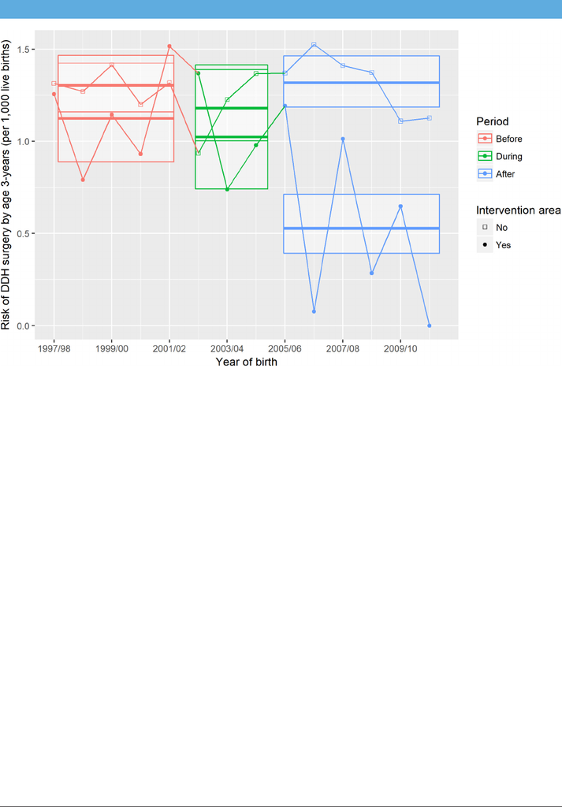

Original article

Figure 2 Risk of ﬁrst surgical intervention by age 3 years, before, during and after introduction of enhanced developmental dysplasia of the hip

(DDH) detection comparing intervention and non-intervention areas.Points represent risk of surgery per 1000 live births for each ﬁnancial year by

intervention versus non-intervention areas. For each combination of timeperiod and area, the bold horizontal lines and upper and lower edges of

the crossbars represent, respectively, point estimates and upper and lower 95% CIs, which were obtained from the difference-in-difference logistic

regression model of risk of surgery on area and timeperiod.

protective.

21

However, universal ultrasound was offered at that

time in Germany. As such, children who did and did not undergo

ultrasound scanning might differ in their risk of developing DDH,

or in being diagnosed and undergoing surgery between the ages of

9 weeks and 5 years. For example, parents unwilling for their child

to participate in screening might also be less likely to fully engage

with abduction harnessing, which depends on parental concor-

dance.

22

Alternatively, participation in the screening programme

may be higher among those with one or more established risk

factors for DDH (such as female sex, breech presentation and

family history

23

), thereby increasing risk.

In contrast, to act as a confounder in our study, any increase in

the prevalence of risk factors for DDH, or changes in the diag-

nosis and treatment of DDH would need to have differed across

intervention areas and non-intervention areas and done so at the

same time that the enhanced detection services were introduced.

It is more probable that the introduction of enhanced DDH

detection services did in fact reduce late diagnosis of DDH and

hence unnecessary surgery.

In absolute terms, the estimated risk of DDH surgery aged

3 in the postintervention period was 0.54 per 1000 live births.

Studies vary in definitions and follow-up. Nonetheless, this

finding is consistent with rates achieved internationally: Clegg

et al (Coventry, UK) 0.6/1000,

11

Clarke et al (Southampton,

UK) 0.74/1000,

12

Duppe et al (Malmo, Sweden) 0.16/1000,

10

Holen et al (Trondheim, Norway) 0.65/1000,

24

Myers et al

(New Zealand) 0.29/1000

25

and Laborie et al (Bergen, Norway)

0.38/1000.

26

In each of these studies, some form of enhanced

detection method was used. In the case of Clegg et al, universal

ultrasound scanning was performed while Duppe, Holen and

Myers describe the hip examination being carried out by experi-

enced paediatricians or orthopaedic staff. It is notable in Clarke’s

series that almost 20% of newborns were referred to specialist

hip clinics where expert assessment was available.

In the context of such international comparisons, however,

the estimated 3-year risk of 1.3 per 1000 live births in non-in-

tervention areas for the same period appears to be excessively

high. Indeed, if the relationship is causal, around 25 operations

per year may be preventable in other regions of Scotland via the

introduction of enhanced neonatal detection services similar to

those introduced in NHS Lothian and Fife.

Unfortunately, as this study was not designed as an interven-

tion study, we are unable to make strong recommendations as to

the form which enhanced DDH detection should take. Never-

theless, the success of these diverse approaches support the view

that the benefit of an enhanced service depend less on particular

characteristics such as whether the enhanced service is weighted

towards greater use of ultrasound or expert examiners than on

whether it concentrates experience.

19 24

Moreover, a feature

common to both approaches is that direct physical examination

(and/or ultrasound) by staff members with a specialist DDH role

only took place in a minority of children. As such, we speculate

that improved training in examination and education as to the

importance of DDH detection among the wider staff may be an

important component of a successful service-level intervention.

One unexpected finding in our analysis was that children in

the most deprived quintile are least likely to undergo surgery.

The reasons for this are unknown, but we speculate that greater

[figure not shown]

Original article

involvement of health professionals (such as health visitors) in

children born to socioeconomically deprived parents, and hence

greater opportunities for early detection, may be one possible

explanation.

One limitation of our study is that some of the children may

have moved residence between DDH detection and surgery. Any

such imbalance between numerator and denominator is likely

to be minor, however, and appears unlikely to be differential

across both time period and intervention area. Nor is there any

evidence that international inward migration to the interven-

tion areas compared with the non-intervention areas differed

over the study period (see Appendix in the online Supplemen-

tary data).

We also note that we were only able to explore surgical

management of DDH. Due to the nature of the administrative

healthcare data used we were unable to include radiological

aspects, non-surgical management or patient reported outcomes.

A health-economic evaluation including the costs and quality of

life impacts of both the possibility of increased ultrasound scan-

ning and the potential increased use of abduction harnessing

would be of considerable interest.

An additional limitation is the lack of a publicly depos-

ited pre-specified analysis plan. Nonetheless, the results were

extremely robust to sensitivity analyses varying the time periods,

demonstrating that the choice of different cut-points would not

have importantly affected the results.

CONCLUSION

The implementation of enhanced DDH detection services can

produce substantial reductions in late diagnosis of DDH and

associated requirement for surgical correction.

Acknowledgements We would like to acknowledge the contribution of Dr

James Chalmers and the Information Services Division clinical coding and quality

improvement teams. We would also like to acknowledge the contribution of Dr

Robert Humphries who provided data from NHS Fife. We would also like to thank

Professor RW Paton of the Department of Orthopaedics, Royal Blackburn Hospital,

East Lancashire Hospitals NHS Trust, UK for making useful suggestions to improve

the manuscript.

Contributors DM and JM contributed to study design, analysed and interpreted

the data, drafted and revised the manuscript. MR revised the manuscript. CF, AM and

RW designed the study, interpreted the data and revised the manuscript.

Funding DM is funded via an Intermediate Clinical Fellowship (and Beit Fellowship)

from the Wellcome Trust (201492/Z/16/Z). JM is funded via a Clinician Scientist

Fellowship from the Medical Research Council. Neither sponsor had any role in the

design, analysis or reporting of this work.

Competing interests None declared.

Provenance and peer review Not commissioned; externally peer reviewed.

Data sharing statement All data can be obtained from the Information Services

Division, NHS National Services Scotland via established data access policies. Contact

ISD’s Electronic Data Research and Innovation Service (http://www. isdscotland. org/

Products- and- Services/ eDRIS/).

Open access This is an open access article distributed in accordance with the

Creative Commons Attribution Non Commercial (CC BY-NC 4.0) license, which

permits others to distribute, remix, adapt, build upon this work non-commercially,

and license their derivative works on different terms, provided the original work

is properly cited and the use is non-commercial. See: http:// creativecommons. org/

licenses/ by- nc/ 4. 0/

© Article author(s) (or their employer(s) unless otherwise stated in the text of the

article) 2018. All rights reserved. No commercial use is permitted unless otherwise

expressly granted.

RefeRences

1 Bialik V, Bialik GM, Blazer S, etal. Developmental dysplasia of the hip: a new

approach to incidence. Pediatrics 1999;103:93–9.

2 Cashman JP, Round J, Taylor G, etal. The natural history of developmental dysplasia

of the hip after early supervised treatment in the Pavlik harness. A prospective,

longitudinal follow-up. J Bone Joint Surg Br 2002;84:418–25.

3 Ömeroğlu H, Köse N, Akceylan A. Success of Pavlik harness treatment decreases in

patients ≥ 4 months and in ultrasonographically dislocated hips in developmental

dysplasia of the hip. Clin Orthop Relat Res 2016;474:1146–52.

4 Pollet V, Pruijs H, Sakkers R, etal. Results of Pavlik harness treatment in children with

dislocated hips between the age of six and twenty-four months. J Pediatr Orthop

2010;30:437–42.

5 Shorter D, Hong T, Osborn DA. Cochrane Neonatal Group. Screening programmes

for developmental dysplasia of the hip in newborn infants. Cochrane database of

systematic reviews. 360: John Wiley & Sons, Ltd, 2011.

6 Newborn and infant physical examination screening: programme overview– GOV.UK.

https://www. gov. uk/ guidance/ newborn- and- infant- physical- examination- screening-

programme- overview (accessed 11 May 2017).

7 Shaw BA, Segal LS. Section on orthopaedics. Evaluation and referral for

developmental dysplasia of the hip in infants. Pediatrics 2016;138:e20163107.

8 Final Recommendation Statement. Developmental hip dysplasia: screening– US

preventive services task force. https://www. uspr even tive serv ices task force. org/ Page/

Document/ Reco mmen dati onSt atem entFinal/ developmental- hip- dysplasia- screening

(accessed 11 May 2017).

9 von Kries R, Ihme N, Oberle D, etal. Effect of ultrasound screening on the rate

of ﬁrst operative procedures for developmental hip dysplasia in Germany. Lancet

2003;362:1883–7.

10 Düppe H, Danielsson LG. Screening of neonatal instability and of developmental

dislocation of the hip. A survey of 132,601 living newborn infants between 1956 and

1999. J Bone Joint Surg Br 2002;84:878–85.

11 Clegg J, Bache CE, Raut VV. Financial justiﬁcation for routine ultrasound screening of

the neonatal hip. J Bone Joint Surg Br 1999;81:852–7.

12 Clarke NM, Reading IC, Corbin C, etal. Twenty years experience of selective

secondary ultrasound screening for congenital dislocation of the hip. Arch Dis Child

2012;97:423–9.

13 Godward S, Dezateux C. Surgery for congenital dislocation of the hip in the UK as a

measure of outcome of screening. MRC Working Party on Congenital Dislocation of

the Hip. Medical Research Council. Lancet 1998;351:1149–52.

14 National Records of Scotland. https://www. nrscotland. gov. uk/ statistics- and- data/

statistics/ statistics- by- theme/ vital- events. Published May 31, 2013. (accessed 1 May

2017).

15 SMR Datasets | ISD Scotland | Data Dictionary. http://www. ndc. scot. nhs. uk/ Data-

Dictionary/ SMR- Datasets/ (accessed 1 May 2017).

16 Newborn and infant physical examination screening: programme overview - GOV. UK.

https:// www. gov. uk/ guidance/ newborn- and- infant- physical- examination- screening-

programme- overview (accessed 1 May 2017).

17 Scottish Government SAH. Scottish index of multiple deprivation. http://www. gov.

scot/ Topics/ Statistics/ SIMD (accessed 9 May 2017).

18 Brown LD, Cai TT, DasGupta A. Interval estimation for a binomial proportion. Stat Sci

2001;16:101–33.

19 Rosendahl K, Markestad T, Lie RT. Ultrasound screening for developmental dysplasia

of the hip in the neonate: the effect on treatment rate and prevalence of late cases.

Pediatrics 1994;94:47–52.

20 Thaler M, Biedermann R, Lair J, etal. Cost-effectiveness of universal ultrasound

screening compared with clinical examination alone in the diagnosis and treatment of

neonatal hip dysplasia in Austria. J Bone Joint Surg Br 2011;93:1126–30.

21 von Kries R, Ihme N, Altenhofen L, etal. General ultrasound screening reduces the

rate of ﬁrst operative procedures for developmental dysplasia of the hip: a case-

control study. J Pediatr 2012;160:271–5.

22 Mubarak S, Garﬁn S, Vance R, etal. Pitfalls in the use of the Pavlik harness for

treatment of congenital dysplasia, subluxation, and dislocation of the hip. J Bone Joint

Surg Am 1981;63:1239–48.

23 de Hundt M, Vlemmix F, Bais JM, etal. Risk factors for developmental dysplasia of the

hip: a meta-analysis. Eur J Obstet Gynecol Reprod Biol 2012;165:8–17.

24 Holen KJ, Tegnander A, Bredland T, etal. Universal or selective screening of the

neonatal hip using ultrasound? A prospective, randomised trial of 15,529 newborn

infants. J Bone Joint Surg Br 2002;84:886–90.

25 Myers J, Hadlow S, Lynskey T. The effectiveness of a programme for neonatal hip

screening over a period of 40 years: a follow-up of the New Plymouth experience.

J Bone Joint Surg Br 2009;91:245–8.

26 Laborie LB, Markestad TJ, Davidsen H, etal. Selective ultrasound screening for

developmental hip dysplasia: effect on management and late detected cases. A

prospective survey during 1991–2006. Pediatr Radiol 2014;44:410–24.